# Mastering the tidyverse

# 1 Welcome!

This tutorial is partly based on the book “R for Data Science” which is freely available here: http://r4ds.had.co.nz/

## 1.1 What do you need to follow along?

## 1.2 Why data manipulation and visualization?

The core component of any data analytics project is **data**. Understanding and manipulating data is crucial to:

- Define the scope of a project: know what is possible with the current data, etc.
- Prepare different data workflows. Data is rarely usable in raw form, some transformations need to be applied to it before modelling. *Garbage in, garbage out!*.
- Present the results. Every analysis we do needs to have a **why**. Very often the outcome of this analysis needs to be communicated to decision makers or non-experts.

In this course we will use the `tidyverse`, which is a coherent set of packages for the full lifecycle of a data science project.

Let’s import the `tidyverse` library, which is a wrapper for all eight packages (as of 2018).

```r
library(tidyverse)
```

If this is not installed in your system, you need to `install.packages("tidyverse")` first.

# 2 Data manipulation with `dplyr`

We turn now to `dplyr`. This package provides a function for each basic action with data:

- `filter()` (and `slice()`)
- `arrange()`
- `select()` (and `rename()`)
- `distinct()`
- `mutate()` (and `transmute()`)
- `summarise()`
- `sample_n()` (and `sample_frac()`)

which can do many things together with the “%>%” (read “and then”)

We will use the [Online News Popularity](http://archive.ics.uci.edu/ml/datasets/Online+News+Popularity) data.

Let’s start by loading it, and keep only a part:

```r
news<-read.csv("OnlineNewsPopularity.csv")[2:5]
head(news) # Too many columns
```

```
##   timedelta n_tokens_title n_tokens_content n_unique_tokens
## 1       731             12              219       0.6635945
## 2       731              9              255       0.6047431
## 3       731              9              211       0.5751295
## 4       731              9              531       0.5037879
## 5       731             13             1072       0.4156456
## 6       731             10              370       0.5598886
```

We can use some base `R` functions to understand a bit what is going on:

```r
table(news$data_channel_is_lifestyle)
```

```
## < table of extent 0 >
```

Or even something like this:

```r
table(news$data_channel_is_lifestyle, news$data_channel_is_bus)
```

```
## < table of extent 0 x 0 >
```

But as we will see, things get messy when the questions to our data become harder!

Let’s say we want the articles from a specific day:

```r
# Filter the articles from a specific day
oldest <- dplyr::filter(news, timedelta == 731 )
head(oldest, n = 2)
```

```
##   timedelta n_tokens_title n_tokens_content n_unique_tokens
## 1       731             12              219       0.6635945
## 2       731              9              255       0.6047431
```

or, using the operator %>%:

```r
news %>% dplyr::filter(timedelta==731) %>% head(n=2)
```

```
##   timedelta n_tokens_title n_tokens_content n_unique_tokens
## 1       731             12              219       0.6635945
## 2       731              9              255       0.6047431
```

In pure R (without dplyr), we can do

```r
oldest <- news[news$timedelta==731,]
head(oldest, n = 2 )
```

```
##   timedelta n_tokens_title n_tokens_content n_unique_tokens
## 1       731             12              219       0.6635945
## 2       731              9              255       0.6047431
```

### 2.0.1 filter()

```r
# Filter the articles from a specific day
oldest <- dplyr::filter(news, timedelta == 731 )
head(oldest, n = 2)
```

```
##   timedelta n_tokens_title n_tokens_content n_unique_tokens
## 1       731             12              219       0.6635945
## 2       731              9              255       0.6047431
```

or, using the operator %>%:

```r
news %>% dplyr::filter(timedelta==731) %>% head(n=2)
```

```
##   timedelta n_tokens_title n_tokens_content n_unique_tokens
## 1       731             12              219       0.6635945
## 2       731              9              255       0.6047431
```

In pure R (without dplyr), we can do

```r
oldest <- news[news$timedelta==731,]
head(oldest, n = 2 )
```

```
##   timedelta n_tokens_title n_tokens_content n_unique_tokens
## 1       731             12              219       0.6635945
## 2       731              9              255       0.6047431
```

### 2.0.2 slice()

slice() filters rows by position, for instance:

```r
slice(news, 16:20)
```

```
##   timedelta n_tokens_title n_tokens_content n_unique_tokens
## 1       731             12              682       0.4595420
## 2       731              8             1118       0.5123967
## 3       731              8              397       0.6246787
## 4       731             11              103       0.6893204
## 5       731              8             1207       0.4105793
```

### 2.0.3 arrange()

arrange() orders columns and helps to break ties.

```r
news %>%
  arrange(timedelta, n_tokens_title, n_tokens_content) %>%
  head(n=3)
```

```
##   timedelta n_tokens_title n_tokens_content n_unique_tokens
## 1         8              6              682       0.5394933
## 2         8              8             2509       0.3488781
## 3         8             10              157       0.7019868
```

We can use desc() to arrange a column in descending order.

```r
news %>%
  arrange(desc(timedelta), n_tokens_title, n_tokens_content) %>%
  head(n=3)
```

```
##   timedelta n_tokens_title n_tokens_content n_unique_tokens
## 1       731              5              356       0.6182336
## 2       731              6              109       0.6666667
## 3       731              6              174       0.6918605
```

### 2.0.4 select()

We can use select to, well, select specific columns:

```r
news %>% select(timedelta,n_tokens_content) %>% head(n=2)
```

```
##   timedelta n_tokens_content
## 1       731              219
## 2       731              255
```

```r
news %>% select(-c(n_tokens_title,n_tokens_content)) %>% head(n=2)
```

```
##   timedelta n_unique_tokens
## 1       731       0.6635945
## 2       731       0.6047431
```

We can use select() also to rename columns

```r
news %>% select(words_in_title = n_tokens_title) %>% head(n=3)
```

```
##   words_in_title
## 1             12
## 2              9
## 3              9
```

### 2.0.5 rename()

This is useful to rename a column without dropping the other variables

```r
news %>% rename(words_in_title = n_tokens_title) %>% head(n=3)
```

```
##   timedelta words_in_title n_tokens_content n_unique_tokens
## 1       731             12              219       0.6635945
## 2       731              9              255       0.6047431
## 3       731              9              211       0.5751295
```

### 2.0.6 distinct()

This function allows us to find unique values in a table

```r
news %>% distinct(timedelta) %>% head(n=3)
```

```
##   timedelta
## 1       731
## 2       730
## 3       729
```

```r
news %>% distinct(timedelta,n_tokens_title) %>% nrow
```

```
## [1] 6792
```

### 2.0.7 mutate()

Sometimes we need to add new columns that are function of existing columns, for instance:

```r
news %>%
  mutate(title_to_content = n_tokens_title/n_tokens_content
         ,total_unique = n_tokens_content * n_unique_tokens ) %>%
  head(n=3)
```

```
##   timedelta n_tokens_title n_tokens_content n_unique_tokens
## 1       731             12              219       0.6635945
## 2       731              9              255       0.6047431
## 3       731              9              211       0.5751295
##   title_to_content total_unique
## 1       0.05479452     145.3272
## 2       0.03529412     154.2095
## 3       0.04265403     121.3523
```

We can recycle newly created variables!

```r
news %>%
  mutate(title_to_content = n_tokens_title/n_tokens_content
         ,percentage = round(100*title_to_content,2) ) %>%
  head(n=3)
```

```
##   timedelta n_tokens_title n_tokens_content n_unique_tokens
## 1       731             12              219       0.6635945
## 2       731              9              255       0.6047431
## 3       731              9              211       0.5751295
##   title_to_content percentage
## 1       0.05479452       5.48
## 2       0.03529412       3.53
## 3       0.04265403       4.27
```

### 2.0.8 transmute()

Like mutate(), but keeps only the newly created variables

```r
news %>%
  transmute(title_to_content = n_tokens_title/n_tokens_content
         ,total_unique = n_tokens_content * n_unique_tokens ) %>%
  head(n=3)
```

```
##   title_to_content total_unique
## 1       0.05479452     145.3272
## 2       0.03529412     154.2095
## 3       0.04265403     121.3523
```

### 2.0.9 Sampling: sample_n() and sample_frac()

These two functions allow us to sample randomly a fixed number of rows or a fraction. Use replace = TRUE for a sample with replacement, and you can add weights for the sampling if needed. More info in ?sample_n

### 2.0.10 Grouping functions

All the functions above become really useful when we can apply them to groups. Let’s load again the data, this time the full data frame:

```r
news<-read.csv("OnlineNewsPopularity.csv")
```

```r
gps <- news %>%
  sample_frac(.1)%>%
  group_by(data_channel_is_lifestyle
          ,data_channel_is_world)%>%
  summarise(count=n()
            ,avg_imgs = mean(num_imgs, na.rm = TRUE)
            , avg_videos =mean(num_videos, na.rm = TRUE))
```

### 2.0.11 Plotting the final results

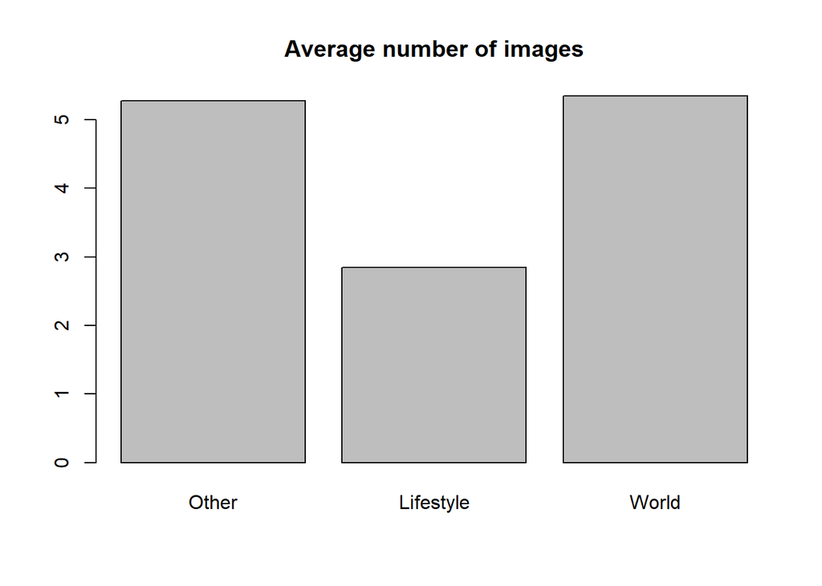

```r
barplot(gps$avg_imgs
        , names.arg = c("Other", "Lifestyle", "World")
        , main = "Average number of images")
```

### 2.0.12 Another useful plot

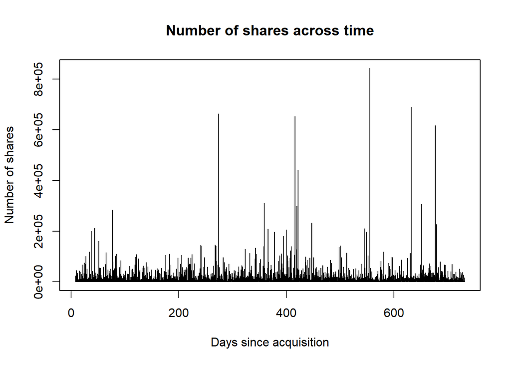

```r
plot(news$timedelta,news$shares
     , type='l', main = "Number of shares across time"
     , xlab = "Days since acquisition", ylab = "Number of shares")
```

Let’s test some hypothesis:

- What are the 5 most shared articles?
- Which channel (among the six described) has the largest average number of shares? does it change across time?
- Which day has the most shares, on average?

What are the 5 most shared articles?

```r
news %>% arrange(desc(shares)) %>% select(url,shares) %>% head(n=5)
```

```
##                                                                   url
## 1                     http://mashable.com/2013/07/03/low-cost-iphone/
## 2             http://mashable.com/2013/04/15/dove-ad-beauty-sketches/
## 3 http://mashable.com/2014/04/09/first-100-gilt-soundcloud-stitchfix/
## 4          http://mashable.com/2013/11/18/kanye-west-harvard-lecture/
## 5                   http://mashable.com/2013/03/02/wealth-inequality/
##   shares
## 1 843300
## 2 690400
## 3 663600
## 4 652900
## 5 617900
```

Which channel has the largest number of shares?

```r
ex2a <- news %>%
  group_by(data_channel_is_lifestyle
  , data_channel_is_entertainment
  , data_channel_is_bus
  , data_channel_is_socmed
  , data_channel_is_tech
  , data_channel_is_world)%>%
  summarise(avg_shares = mean(shares))
```

… and the plot:

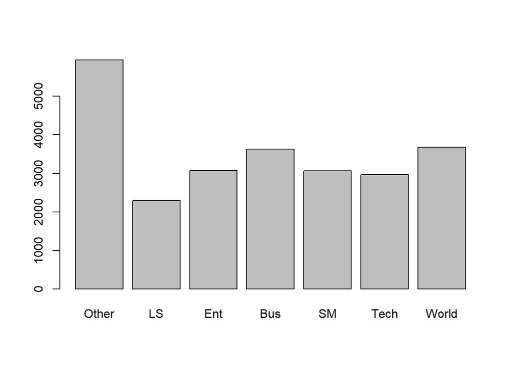

```r
barplot(ex2a$avg_shares,
        names.arg =c("Other","LS","Ent","Bus","SM","Tech","World"))
```

Does it change with time?

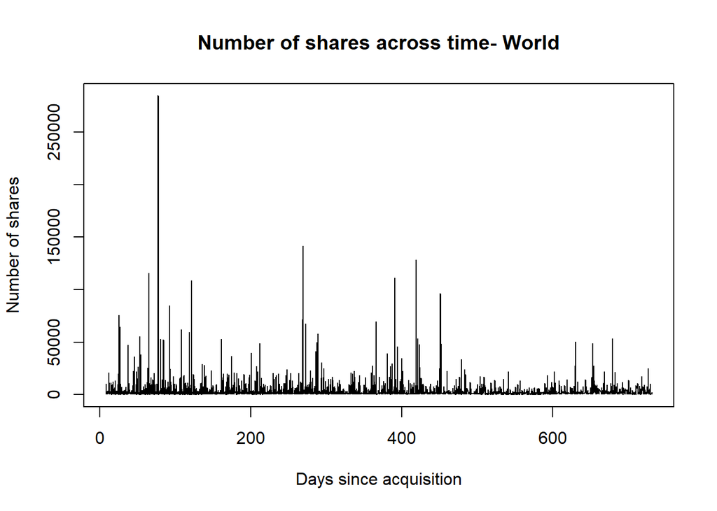

```r
ex2b <- news %>% dplyr::filter(data_channel_is_world ==1)

plot(ex2b$timedelta,ex2b$shares
     , type='l', main = "Number of shares across time- World"
     , xlab = "Days since acquisition", ylab = "Number of shares")
```

Which day has the most shares, on average?

```r
ex3 <- news %>%
  group_by(weekday_is_monday
  , weekday_is_tuesday
  , weekday_is_wednesday
  , weekday_is_thursday
  , weekday_is_friday
  , weekday_is_saturday
  , weekday_is_sunday)%>%
  summarise(avg_shares = mean(shares))
```

and the plot:

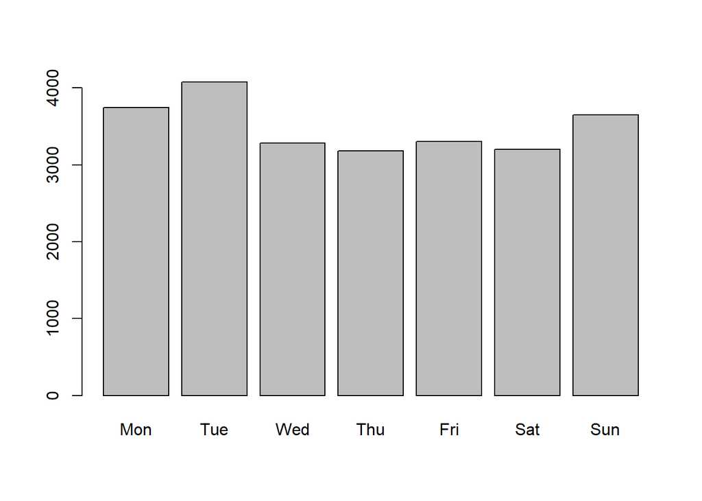

```r
barplot(ex3$avg_shares,
        names.arg =c("Mon", "Tue",'Wed', "Thu", "Fri", "Sat", "Sun"))
```

# 3 Data Visualization with `ggplot2`

We will use as our running example the `mpg` data set available with the `tidyverse`.

Let’s take a look first:

```r
head(mpg)
```

```
## # A tibble: 6 x 11
##   manufacturer model displ  year   cyl trans drv     cty   hwy fl    class
##   <chr>        <chr> <dbl> <int> <int> <chr> <chr> <int> <int> <chr> <chr>
## 1 audi         a4      1.8  1999     4 auto~ f        18    29 p     comp~
## 2 audi         a4      1.8  1999     4 manu~ f        21    29 p     comp~
## 3 audi         a4      2    2008     4 manu~ f        20    31 p     comp~
## 4 audi         a4      2    2008     4 auto~ f        21    30 p     comp~
## 5 audi         a4      2.8  1999     6 auto~ f        16    26 p     comp~
## 6 audi         a4      2.8  1999     6 manu~ f        18    26 p     comp~
```

This data set contains information about different cars. For more info on what these variables mean, try `?mpg`.

## 3.1 Baseline: Base R charts

Suppose we want to plot the highway miles per gallon (`mpg$hwy`) as a function of engine displacement (`mpg$displ`). `R` comes with basic plotting functionality. We could do this, for instance, with the following command:

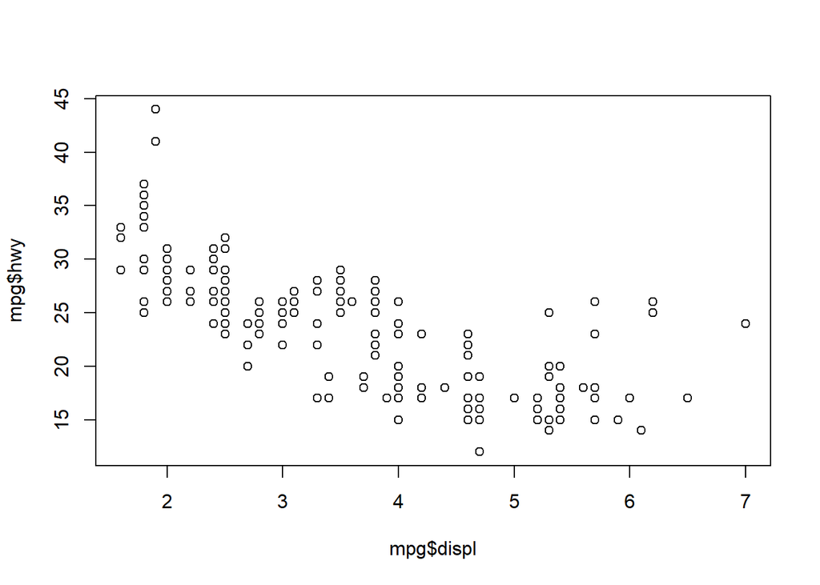

```r
plot(mpg$displ, mpg$hwy)
```

This is of course, ugly. We can add some formatting to make it nicer.

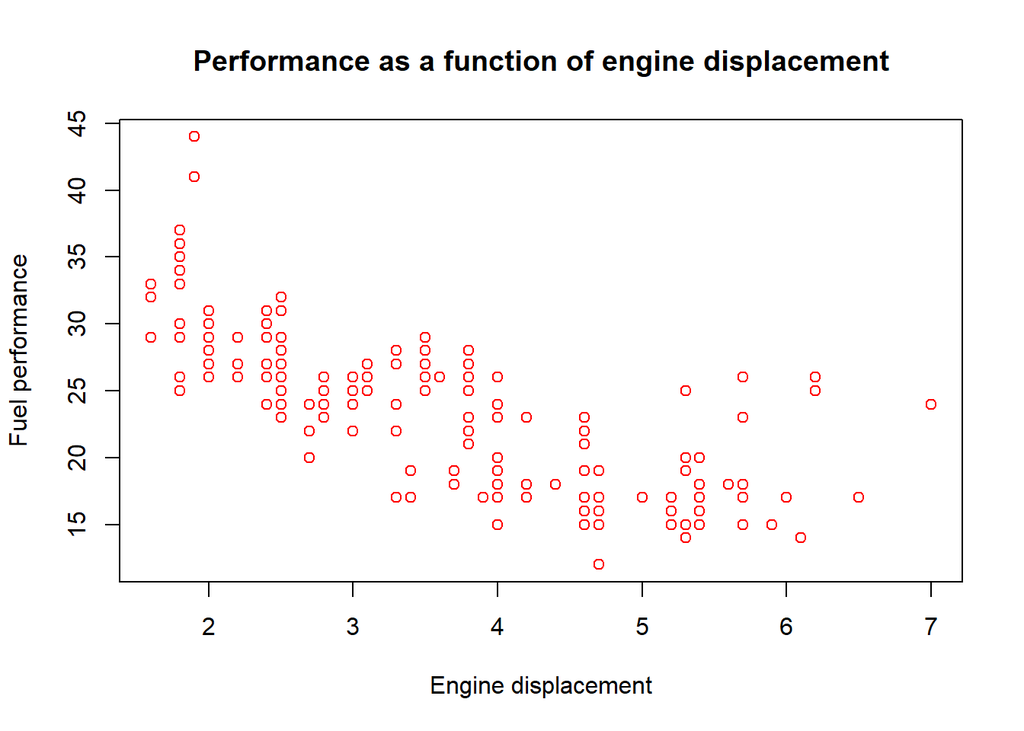

```r
plot(mpg$displ, mpg$hwy,
     main="Performance as a function of engine displacement",
     xlab ="Engine displacement", ylab="Fuel performance",
     col='red')
```

How did I know this commands? Simply use `?plot` to display the help on the side menu in RStudio. That’s fine for a simple plot, but when we are doing data exploration (aka Exploratory Data Analysis), this is not always efficient.